# Step 1 — Data Preparation

```python
import pandas as pd
import numpy as np
import matplotlib.pyplot as plt
import matplotlib.dates as mdates
import os
import warnings

warnings.filterwarnings('ignore')

for folder in ['tables', 'plots', 'data']:
    os.makedirs(folder, exist_ok=True)

plt.rcParams['figure.dpi'] = 120
plt.rcParams['font.size'] = 11

DATA_FILE = 'data_hec_projet_1.xlsx'
```

## Load raw data

metadata fills the first 5 rows, so we skip them.

```python
daily_raw = pd.read_excel(DATA_FILE, sheet_name='Daily', header=5, index_col=0, parse_dates=True)
monthly_raw = pd.read_excel(DATA_FILE, sheet_name='Monthly', header=5, index_col=0, parse_dates=True)

print('Daily:', daily_raw.shape, '|', daily_raw.index[0].date(), 'to', daily_raw.index[-1].date())
print('Monthly:', monthly_raw.shape, '|', monthly_raw.index[0].date(), 'to', monthly_raw.index[-1].date())
print()
print('Daily columns:', list(daily_raw.columns))
print('Monthly columns:', list(monthly_raw.columns))
```

```
Daily: (9443, 13) | 1990-01-01 to 2026-03-11
Monthly: (435, 8) | 1989-12-31 to 2026-02-28

Daily columns: ['PX_LAST', 'PX_LAST.1', 'PX_LAST.2', 'PX_LAST.3', 'PX_LAST.4', 'PX_LAST.5', 'PX_LAST.6', 'PX_LAST.7', 'PX_LAST.8', 'PX_LAST.9', 'PX_LAST.10', 'PX_LAST.11', 'PX_LAST.12']
Monthly columns: ['PX_LAST', 'PX_LAST.1', 'PX_LAST.2', 'PX_LAST.3', 'PX_LAST.4', 'PX_LAST.5', 'PX_LAST.6', 'PX_LAST.7']
```

```python
# column positions from the output
daily_cols = {
    daily_raw.columns[1]: 'brent',
    daily_raw.columns[6]: 'msci_world',
    daily_raw.columns[7]: 'msci_em',
    daily_raw.columns[9]: 'us10y',
}
daily = daily_raw[list(daily_cols.keys())].rename(columns=daily_cols).copy()

monthly_cols = {
    monthly_raw.columns[0]: 'ip',
    monthly_raw.columns[1]: 'cfnai',
    monthly_raw.columns[2]: 'ism',
}
monthly = monthly_raw[list(monthly_cols.keys())].rename(columns=monthly_cols).copy()

daily.head(3)
```

| Dates | brent | msci_world | msci_em | us10y |
| --- | --- | --- | --- | --- |
| 1990-01-01 | 19.69 | 567.34 | 214.69 | 7.935 |
| 1990-01-02 | 19.90 | 568.96 | 217.30 | 7.930 |
| 1990-01-03 | 20.95 | 569.10 | 220.45 | 7.974 |

## Clean data and compute returns

```python
# Dataset treats missing values as the string '#N/A N/A'
daily = daily.replace('#N/A N/A', np.nan).apply(pd.to_numeric, errors='coerce')
monthly = monthly.replace('#N/A N/A', np.nan).apply(pd.to_numeric, errors='coerce')

daily = daily.dropna(how='all')

print('After cleaning:')
print('Daily:', daily.shape[0], 'obs,', daily.index[0].date(), 'to', daily.index[-1].date())
print('Monthly:', monthly.shape[0], 'obs')
print()
print(daily.isna().sum())
```

```
After cleaning:
Daily: 9443 obs, 1990-01-01 to 2026-03-11
Monthly: 435 obs

brent         0
msci_world    0
msci_em       0
us10y         0
dtype: int64
```

```python
# log-returns: r_t = ln(P_t / P_{t-1})
daily['roil'] = np.log(daily['brent'] / daily['brent'].shift(1))
daily['rworld'] = np.log(daily['msci_world'] / daily['msci_world'].shift(1))
daily['rem'] = np.log(daily['msci_em'] / daily['msci_em'].shift(1))

# yield changes (first difference, not log for rates)
daily['rrate'] = daily['us10y'].diff()

# asymmetric oil decomposition: Oil+ and Oil-
daily['oil_pos'] = np.where(daily['roil'] > 0, daily['roil'], 0)
daily['oil_neg'] = np.where(daily['roil'] < 0, daily['roil'], 0)

df_daily = daily[['roil', 'rworld', 'rem', 'rrate', 'oil_pos', 'oil_neg']].dropna()

print(df_daily.shape)
df_daily.head()
```

```
(9442, 6)
```

| Dates | roil | rworld | rem | rrate | oil_pos | oil_neg |
| --- | --- | --- | --- | --- | --- | --- |
| 1990-01-02 | 0.010609 | 0.002851 | 0.012084 | -0.005 | 0.010609 | 0.000000 |
| 1990-01-03 | 0.051419 | 0.000246 | 0.014392 | 0.044 | 0.051419 | 0.000000 |
| 1990-01-04 | -0.008148 | 0.003368 | 0.030600 | -0.002 | 0.000000 | -0.008148 |
| 1990-01-05 | -0.001445 | -0.008194 | 0.007058 | 0.012 | 0.000000 | -0.001445 |
| 1990-01-08 | -0.052435 | 0.002821 | -0.008864 | 0.028 | 0.000000 | -0.052435 |

## Build monthly dataset

Monthly oil return = sum of daily log-returns in the month (equivalent to ln(P_end / P_start)). For equities we take end-of-month prices and compute log-returns from those.

```python
roil_monthly = daily['roil'].resample('ME').sum().rename('roil_monthly')

# end-of-month prices, then monthly log-returns
world_eom = daily['msci_world'].resample('ME').last()
em_eom = daily['msci_em'].resample('ME').last()
us10y_eom = daily['us10y'].resample('ME').last()

rworld_m = np.log(world_eom / world_eom.shift(1)).rename('rworld_monthly')
rem_m = np.log(em_eom / em_eom.shift(1)).rename('rem_monthly')
rrate_m = us10y_eom.diff().rename('rrate_monthly')

# align macro index to end of month before merging
monthly.index = monthly.index + pd.offsets.MonthEnd(0)

df_monthly = pd.concat([roil_monthly, rworld_m, rem_m, rrate_m, monthly], axis=1)
df_monthly = df_monthly.dropna(subset=['roil_monthly'])

# recession dummy: CFNAI below -0.7 is typically associated with recessionary conditions
df_monthly['recession'] = (df_monthly['cfnai'] < -0.7).astype(int)

df_monthly['oil_pos_m'] = np.where(df_monthly['roil_monthly'] > 0, df_monthly['roil_monthly'], 0)
df_monthly['oil_neg_m'] = np.where(df_monthly['roil_monthly'] < 0, df_monthly['roil_monthly'], 0)

print(df_monthly.shape)
print('Recession months (CFNAI < -0.7):', df_monthly['recession'].sum())
df_monthly.head()
```

```
(435, 10)
Recession months (CFNAI < -0.7): 35
```

| Dates | roil_monthly | rworld_monthly | rem_monthly | rrate_monthly | ip | cfnai | ism | recession | oil_pos_m | oil_neg_m |
| --- | --- | --- | --- | --- | --- | --- | --- | --- | --- | --- |
| 1990-01-31 | -0.006113 | NaN | NaN | NaN | 61.7290 | -0.23 | 47.2 | 0 | 0.0 | -0.006113 |
| 1990-02-28 | -0.005123 | -0.045564 | 0.037652 | 0.097 | 62.2896 | 0.55 | 49.1 | 0 | 0.0 | -0.005123 |
| 1990-03-31 | -0.046251 | -0.064181 | -0.149526 | 0.113 | 62.5999 | 0.17 | 49.9 | 0 | 0.0 | -0.046251 |
| 1990-04-30 | -0.059852 | -0.016463 | 0.062736 | 0.394 | 62.4359 | -0.71 | 50.0 | 1 | 0.0 | -0.059852 |
| 1990-05-31 | -0.072835 | 0.098339 | 0.077344 | -0.423 | 62.6258 | 0.02 | 49.5 | 0 | 0.0 | -0.072835 |

## Quick checks

```python
print('Missing - daily:')
print(df_daily.isna().sum())
print()
print('Missing - monthly:')
print(df_monthly.isna().sum())
print()

# any extreme oil moves?
extreme = df_daily[np.abs(df_daily['roil']) > 0.20]
print(f'Days with |roil| > 20%: {len(extreme)}')
print(extreme[['roil']].sort_values('roil'))
```

```
Missing - daily:
roil       0
rworld     0
rem        0
rrate      0
oil_pos    0
oil_neg    0
dtype: int64

Missing - monthly:
roil_monthly      0
rworld_monthly    1
rem_monthly       1
rrate_monthly     1
ip                1
cfnai             1
ism               1
recession         0
oil_pos_m         0
oil_neg_m         0
dtype: int64

Days with |roil| > 20%: 3
                roil
Dates
1991-01-17 -0.385642
2020-03-09 -0.275751
2020-04-21 -0.233813
```

## Save

```python
df_daily.to_csv('data/df_daily.csv')
df_monthly.to_csv('data/df_monthly.csv')
daily[['brent', 'msci_world', 'msci_em', 'us10y']].loc['1990':].to_csv('data/prices_daily.csv')

print('df_daily:', df_daily.shape)
print('df_monthly:', df_monthly.shape)
```

```
df_daily: (9442, 6)
df_monthly: (435, 10)
```

## Overview plots

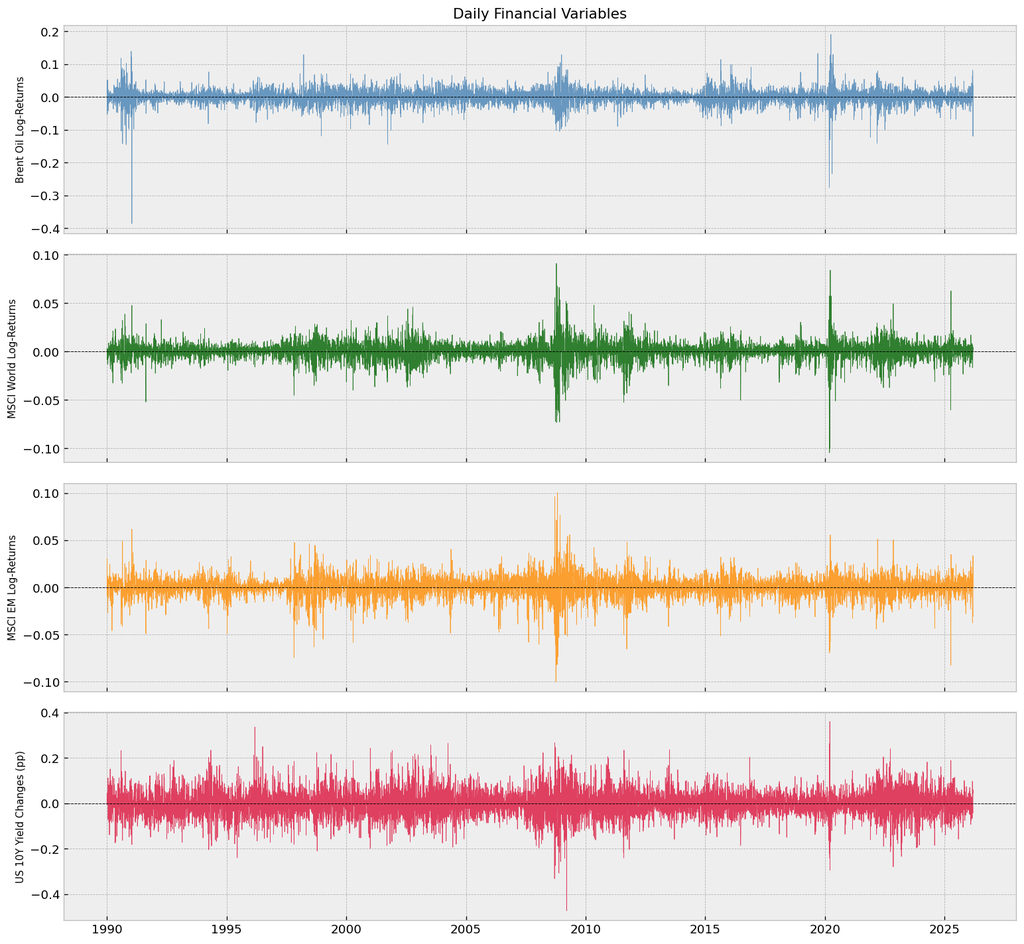

```python
fig, axes = plt.subplots(4, 1, figsize=(13, 12), sharex=True)

vars_daily = [
    ('roil', 'Brent Oil Log-Returns', 'steelblue'),
    ('rworld', 'MSCI World Log-Returns', 'darkgreen'),
    ('rem', 'MSCI EM Log-Returns', 'darkorange'),
    ('rrate', 'US 10Y Yield Changes (pp)', 'crimson'),
]

for ax, (col, label, color) in zip(axes, vars_daily):
    ax.plot(df_daily.index, df_daily[col], color=color, linewidth=0.5, alpha=0.8)
    ax.axhline(0, color='black', linewidth=0.6, linestyle='--')
    ax.set_ylabel(label, fontsize=9)
    ax.xaxis.set_major_locator(mdates.YearLocator(5))
    ax.xaxis.set_major_formatter(mdates.DateFormatter('%Y'))

axes[0].set_title('Daily Financial Variables', fontsize=13)
plt.tight_layout()
plt.savefig('plots/daily_returns_overview.png', bbox_inches='tight')
plt.show()
```

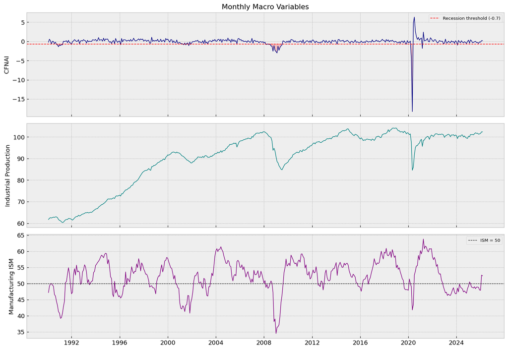

```python
fig, axes = plt.subplots(3, 1, figsize=(13, 9), sharex=True)

ax = axes[0]
ax.plot(df_monthly.index, df_monthly['cfnai'], color='navy', linewidth=1)
ax.axhline(-0.7, color='red', linewidth=1, linestyle='--', label='Recession threshold (-0.7)')
ax.fill_between(df_monthly.index, df_monthly['cfnai'], -0.7,
                where=(df_monthly['cfnai'] < -0.7), color='red', alpha=0.2)
ax.set_ylabel('CFNAI')
ax.legend(fontsize=8)

ax = axes[1]
ax.plot(df_monthly.index, df_monthly['ip'], color='teal', linewidth=1)
ax.set_ylabel('Industrial Production')

ax = axes[2]
ax.plot(df_monthly.index, df_monthly['ism'], color='purple', linewidth=1)
ax.axhline(50, color='black', linewidth=0.8, linestyle='--', label='ISM = 50')
ax.set_ylabel('Manufacturing ISM')
ax.legend(fontsize=8)

axes[0].set_title('Monthly Macro Variables', fontsize=13)
plt.tight_layout()
plt.savefig('plots/monthly_macro_overview.png', bbox_inches='tight')
plt.show()
```

# Step 2 — Preliminary Analysis & Diagnostics

```python
from scipy import stats
from statsmodels.tsa.stattools import adfuller
from statsmodels.tsa.stattools import kpss
from statsmodels.stats.diagnostic import acorr_ljungbox
from statsmodels.graphics.tsaplots import plot_acf


warnings.filterwarnings('ignore')

for folder in ['tables', 'plots']:
    os.makedirs(folder, exist_ok=True)

plt.style.use('bmh')
plt.rcParams['figure.dpi'] = 120
plt.rcParams['font.size'] = 12
plt.rcParams['axes.titlesize'] = 13
plt.rcParams['axes.labelsize'] = 11

df_daily   = pd.read_csv('data/df_daily.csv',   index_col=0, parse_dates=True)
df_monthly = pd.read_csv('data/df_monthly.csv', index_col=0, parse_dates=True)

columns = ['roil', 'rworld', 'rem', 'rrate']
labels = {
    'roil':   'Oil (Brent)',
    'rworld': 'MSCI World',
    'rem':    'MSCI EM',
    'rrate':  'US 10Y Yield Change'
}

columns_monthly = ['roil_monthly', 'rworld_monthly', 'rem_monthly', 'cfnai', 'ip', 'ism']
labels_monthly = {
    'roil_monthly':   'Oil (monthly)',
    'rworld_monthly': 'MSCI World (monthly)',
    'rem_monthly':    'MSCI EM (monthly)',
    'cfnai':          'CFNAI',
    'ip':             'Industrial Production',
    'ism':            'Manufacturing ISM'
}

print('Daily:',   df_daily.shape,   '|', df_daily.index[0].date(),   'to', df_daily.index[-1].date())
print('Monthly:', df_monthly.shape, '|', df_monthly.index[0].date(), 'to', df_monthly.index[-1].date())
```

```
Daily: (9442, 6) | 1990-01-02 to 2026-03-11
Monthly: (435, 10) | 1990-01-31 to 2026-03-31
```

## 1. Descriptive Statistics

```python
rows = []
for col in columns:
    s = df_daily[col].dropna()
    rows.append({
        'Variable':        labels[col],
        'Obs':             len(s),
        'Mean':            s.mean(),
        'Min':             s.min(),
        'Max':             s.max(),
        'Std':             s.std(),
        'Skewness':        s.skew(),
        'Kurtosis':        s.kurtosis() + 3,
        'Excess Kurtosis': s.kurtosis(),
    })

desc_daily = pd.DataFrame(rows).set_index('Variable')
desc_daily.to_csv('tables/desc_stats_daily.csv', float_format='%.4f')
print('Daily returns — descriptive statistics')
print(desc_daily.round(4).to_string())
```

```
Daily returns — descriptive statistics
                      Obs    Mean     Min     Max     Std  Skewness  Kurtosis  Excess Kurtosis
Variable
Oil (Brent)          9442  0.0002 -0.3856  0.1908  0.0219   -0.9530   21.6750          18.6750
MSCI World           9442  0.0002 -0.1044  0.0910  0.0094   -0.5469   13.9677          10.9677
MSCI EM              9442  0.0002 -0.0999  0.1007  0.0111   -0.5542   10.5670           7.5670
US 10Y Yield Change  9442 -0.0004 -0.4736  0.3602  0.0583    0.0517    5.2197           2.2197
```

```python
rows = []
for col in columns_monthly:
    s = df_monthly[col].dropna()
    rows.append({
        'Variable':        labels_monthly[col],
        'Obs':             len(s),
        'Mean':            s.mean(),
        'Std':             s.std(),
        'Min':             s.min(),
        'Max':             s.max(),
        'Skewness':        s.skew(),
        'Excess Kurtosis': s.kurtosis()
    })

desc_monthly = pd.DataFrame(rows).set_index('Variable')
desc_monthly.to_csv('tables/desc_stats_monthly.csv', float_format='%.4f')
print('Monthly variables — descriptive statistics')
print(desc_monthly.round(4).to_string())
```

```
Monthly variables — descriptive statistics
                       Obs     Mean      Std      Min       Max  Skewness  Excess Kurtosis
Variable
Oil (monthly)          435   0.0035   0.0931  -0.6339    0.3660   -0.7909           6.5099
MSCI World (monthly)   434   0.0049   0.0436  -0.2113    0.1192   -0.7939           1.8185
MSCI EM (monthly)      434   0.0044   0.0633  -0.3465    0.1541   -0.9789           3.5062
CFNAI                  434  -0.0733   1.1138 -18.2600    6.3000   -9.7041         167.8761
Industrial Production  434  90.3831  12.8802  60.3346  104.1004   -1.1080          -0.0795
Manufacturing ISM      434  52.2048   4.8842  34.5000   63.8000   -0.5241           0.4938
```

## 2. Distribution Plots

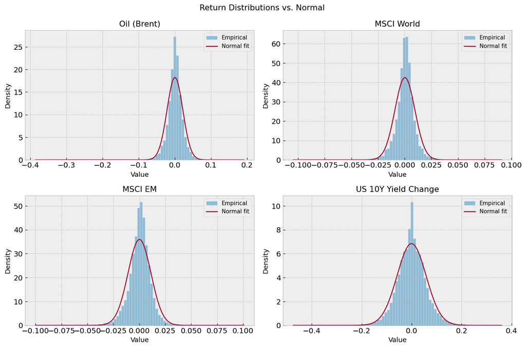

```python
fig, axes = plt.subplots(2, 2, figsize=(12, 8))
axes = axes.flatten()

for i, col in enumerate(columns):
    ax = axes[i]
    s = df_daily[col].dropna()

    ax.hist(s, bins=80, density=True, alpha=0.5, edgecolor='white', linewidth=0.3, label='Empirical')

    x = np.linspace(s.min(), s.max(), 300)
    y_norm = stats.norm.pdf(x, s.mean(), s.std())
    ax.plot(x, y_norm, color='#A60628', linewidth=1.5, label='Normal fit')

    ax.set_title(labels[col])
    ax.set_xlabel('Value')
    ax.set_ylabel('Density')
    ax.legend(fontsize=9)

plt.suptitle('Return Distributions vs. Normal', fontsize=13)
plt.tight_layout()
plt.savefig('plots/distributions_daily.png', bbox_inches='tight')
plt.show()
```

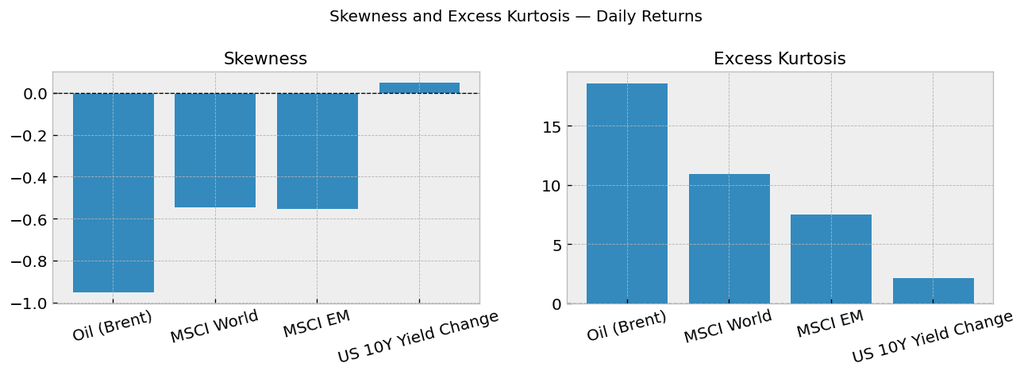

```python
skew_vals = [df_daily[col].dropna().skew()     for col in columns]
kurt_vals = [df_daily[col].dropna().kurtosis() for col in columns]
var_names = [labels[col]                 for col in columns]

fig, axes = plt.subplots(1, 2, figsize=(11, 4))

axes[0].bar(var_names, skew_vals, edgecolor='white')
axes[0].axhline(0, color='black', linewidth=0.8, linestyle='--')
axes[0].set_title('Skewness')
axes[0].tick_params(axis='x', rotation=15)

axes[1].bar(var_names, kurt_vals, edgecolor='white')
axes[1].axhline(0, color='black', linewidth=0.8, linestyle='--')
axes[1].set_title('Excess Kurtosis')
axes[1].tick_params(axis='x', rotation=15)

plt.suptitle('Skewness and Excess Kurtosis — Daily Returns', fontsize=12)
plt.tight_layout()
plt.savefig('plots/skewness_kurtosis.png', bbox_inches='tight')
plt.show()
```

## 3. Normality Tests (Jarque-Bera)

H0 is : the series is normally distributed

```python
rows = []
for col in columns:
    s = df_daily[col].dropna()
    jb_stat, jb_pval = stats.jarque_bera(s)
    rows.append({
        'Variable':       labels[col],
        'JB Statistic':   jb_stat,
        'p-value':        jb_pval,
        'Reject H0 (5%)': 'Yes' if jb_pval < 0.05 else 'No'
    })

jb_df = pd.DataFrame(rows).set_index('Variable')
jb_df.to_csv('tables/jarque_bera.csv', float_format='%.4f')
print(jb_df.round(4).to_string())
```

```
                     JB Statistic  p-value Reject H0 (5%)
Variable
Oil (Brent)           138480.2877      0.0            Yes
MSCI World             47739.0495      0.0            Yes
MSCI EM                22982.5567      0.0            Yes
US 10Y Yield Change     1939.5070      0.0            Yes
```

## 4. Stationarity (Augmented Dickey-Fuller)

H0 is unit root, non-stationary. Lag selection via AIC.

```python
def run_adf(series, name):
    result = adfuller(series.dropna(), autolag='AIC')
    return {
        'Variable':         name,
        'ADF Stat':         result[0],
        'p-value':          result[1],
        'Lags':             result[2],
        '1% CV':            result[4]['1%'],
        '5% CV':            result[4]['5%'],
        '10% CV':           result[4]['10%'],
        'Stationary (5%)':  'Yes' if result[1] < 0.05 else 'No'
    }

rows = [run_adf(df_daily[col], labels[col]) for col in columns]
adf_daily = pd.DataFrame(rows).set_index('Variable')
adf_daily.to_csv('tables/adf_daily.csv', float_format='%.4f')
print('ADF tests — daily returns')
print(adf_daily.round(4).to_string())
```

```
ADF tests — daily returns
                     ADF Stat  p-value  Lags  1% CV   5% CV  10% CV Stationary (5%)
Variable
Oil (Brent)          -22.8277      0.0    15 -3.431 -2.8618 -2.5669             Yes
MSCI World           -22.8671      0.0    17 -3.431 -2.8618 -2.5669             Yes
MSCI EM              -15.6772      0.0    28 -3.431 -2.8618 -2.5669             Yes
US 10Y Yield Change  -19.0854      0.0    22 -3.431 -2.8618 -2.5669             Yes
```

```python
rows = [run_adf(df_monthly[col], labels_monthly[col]) for col in columns_monthly]
adf_monthly = pd.DataFrame(rows).set_index('Variable')
adf_monthly.to_csv('tables/adf_monthly.csv', float_format='%.4f')
print('ADF tests — monthly variables')
print(adf_monthly.round(4).to_string())
```

```
ADF tests — monthly variables
                       ADF Stat  p-value  Lags   1% CV   5% CV  10% CV Stationary (5%)
Variable
Oil (monthly)          -16.8671   0.0000     0 -3.4455 -2.8682 -2.5703             Yes
MSCI World (monthly)   -20.0494   0.0000     0 -3.4455 -2.8682 -2.5703             Yes
MSCI EM (monthly)      -17.9006   0.0000     0 -3.4455 -2.8682 -2.5703             Yes
CFNAI                  -15.2059   0.0000     1 -3.4456 -2.8683 -2.5703             Yes
Industrial Production   -2.0448   0.2673     2 -3.4456 -2.8683 -2.5704              No
Manufacturing ISM       -5.6506   0.0000     9 -3.4459 -2.8684 -2.5704             Yes
```

## 4.2 Stationarity with kpss

```python
def run_kpss(series, name, regression='c'):
    """
    KPSS test
    H0: series is stationary
    H1: series is non-stationary
    """
    result = kpss(series.dropna(), regression=regression, nlags='auto')

    return {
        'Variable': name,
        'KPSS Stat': result[0],
        'p-value': result[1],
        'Lags': result[2],
        '1% CV': result[3]['1%'],
        '5% CV': result[3]['5%'],
        '10% CV': result[3]['10%'],
        'Stationary (5%)': 'Yes' if result[1] >= 0.05 else 'No'
    }

rows = [run_kpss(df_daily[col], labels[col], regression='c') for col in columns]
kpss_daily = pd.DataFrame(rows).set_index('Variable')
kpss_daily.to_csv('tables/kpss_daily.csv', float_format='%.4f')

print('KPSS tests – daily returns')
print(kpss_daily.round(4).to_string())

rows = [run_kpss(df_monthly[col], labels_monthly[col], regression='c') for col in columns_monthly]
kpss_monthly = pd.DataFrame(rows).set_index('Variable')
kpss_monthly.to_csv('tables/kpss_monthly.csv', float_format='%.4f')

print('KPSS tests – monthly variables')
print(kpss_monthly.round(4).to_string())
```

```
KPSS tests – daily returns
                     KPSS Stat  p-value  Lags  1% CV  5% CV  10% CV Stationary (5%)
Variable
Oil (Brent)             0.0453      0.1     9  0.739  0.463   0.347             Yes
MSCI World              0.0893      0.1    14  0.739  0.463   0.347             Yes
MSCI EM                 0.0626      0.1     4  0.739  0.463   0.347             Yes
US 10Y Yield Change     0.1710      0.1    12  0.739  0.463   0.347             Yes
KPSS tests – monthly variables
                       KPSS Stat  p-value  Lags  1% CV  5% CV  10% CV Stationary (5%)
Variable
Oil (monthly)             0.0495     0.10     0  0.739  0.463   0.347             Yes
MSCI World (monthly)      0.0858     0.10     3  0.739  0.463   0.347             Yes
MSCI EM (monthly)         0.0419     0.10     5  0.739  0.463   0.347             Yes
CFNAI                     0.1869     0.10     0  0.739  0.463   0.347             Yes
Industrial Production     2.5963     0.01    12  0.739  0.463   0.347              No
Manufacturing ISM         0.1583     0.10    11  0.739  0.463   0.347             Yes
```

## 5. Time Dependency

Autocorrelation with returns; tests for serial correlation in the mean.

Autocorrelation with squared returns; tests for volatility clustering (ARCH effects).

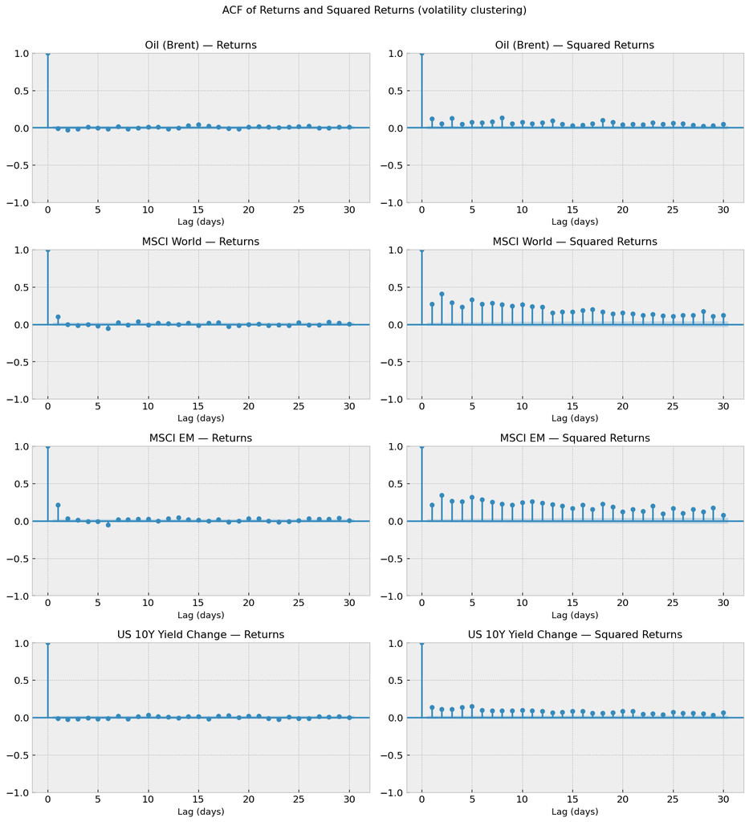

```python
fig, axes = plt.subplots(4, 2, figsize=(13, 14))

for i, col in enumerate(columns):
    s = df_daily[col].dropna()

    plot_acf(s,    lags=30, ax=axes[i, 0], alpha=0.05,
             title=f'{labels[col]} — Returns')
    plot_acf(s**2, lags=30, ax=axes[i, 1], alpha=0.05,
             title=f'{labels[col]} — Squared Returns')

    axes[i, 0].set_xlabel('Lag (days)')
    axes[i, 1].set_xlabel('Lag (days)')

plt.suptitle('ACF of Returns and Squared Returns (volatility clustering)', fontsize=13, y=1.005)
plt.tight_layout()
plt.savefig('plots/acf_returns.png', bbox_inches='tight')
plt.show()
```

```python
# Ljung-Box test at lags 5, 10, 20
# H0: no autocorrelation up to lag k
lags = [5, 10, 20]
rows = []

for col in columns:
    s = df_daily[col].dropna()
    lb_ret = acorr_ljungbox(s,    lags=lags, return_df=True)
    lb_sq  = acorr_ljungbox(s**2, lags=lags, return_df=True)

    for lag in lags:
        rows.append({
            'Variable':           labels[col],
            'Lag':                lag,
            'LB (returns)':       round(lb_ret.loc[lag, 'lb_stat'],    4),
            'p-val (returns)':    round(lb_ret.loc[lag, 'lb_pvalue'],  4),
            'LB (sq. returns)':   round(lb_sq.loc[lag,  'lb_stat'],    4),
            'p-val (sq. ret.)':   round(lb_sq.loc[lag,  'lb_pvalue'],  4)
        })

lb_df = pd.DataFrame(rows)
lb_df.to_csv('tables/ljung_box.csv', index=False, float_format='%.4f')
print(lb_df.to_string(index=False))
print('\nH0: no autocorrelation up to lag k')
```

```
           Variable  Lag  LB (returns)  p-val (returns)  LB (sq. returns)  p-val (sq. ret.)
        Oil (Brent)    5       13.0434           0.0230          397.0580               0.0
        Oil (Brent)   10       20.7534           0.0229          747.6232               0.0
        Oil (Brent)   20       55.9741           0.0000         1144.3593               0.0
         MSCI World    5      100.5484           0.0000         4592.6937               0.0
         MSCI World   10      149.1412           0.0000         7928.8077               0.0
         MSCI World   20      175.0552           0.0000        11052.3442               0.0
            MSCI EM    5      440.9342           0.0000         3815.4698               0.0
            MSCI EM   10      483.9017           0.0000         6721.8080               0.0
            MSCI EM   20      527.2746           0.0000        10663.4769               0.0
US 10Y Yield Change    5       15.2701           0.0093          810.4350               0.0
US 10Y Yield Change   10       33.5632           0.0002         1219.1430               0.0
US 10Y Yield Change   20       54.0512           0.0001         1752.5850               0.0

H0: no autocorrelation up to lag k
```

## 6. Cross-Correlations

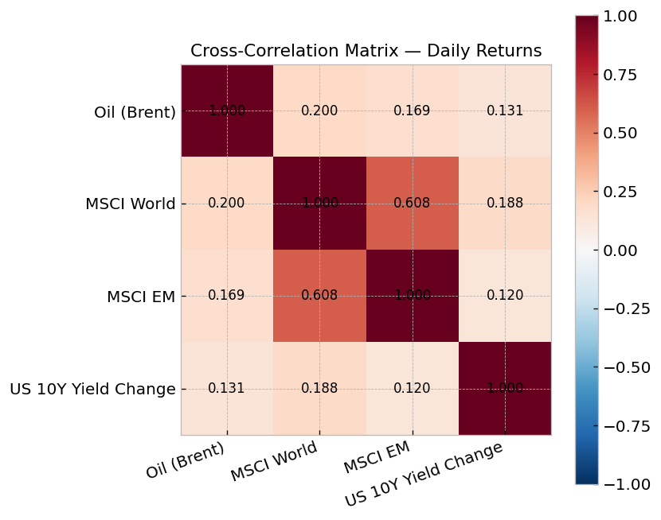

```
                     Oil (Brent)  MSCI World  MSCI EM  US 10Y Yield Change
Oil (Brent)               1.0000      0.1999   0.1688               0.1313
MSCI World                0.1999      1.0000   0.6077               0.1879
MSCI EM                   0.1688      0.6077   1.0000               0.1196
US 10Y Yield Change       0.1313      0.1879   0.1196               1.0000
```

```python
corr = df_daily[columns].corr()
labels = [labels[c] for c in columns]

fig, ax = plt.subplots(figsize=(7, 6))
im = ax.imshow(corr.values, cmap='RdBu_r', vmin=-1, vmax=1)
plt.colorbar(im, ax=ax)

for i in range(len(corr)):
    for j in range(len(corr)):
        ax.text(j, i, f'{corr.iloc[i, j]:.3f}', ha='center', va='center', fontsize=10)

ax.set_xticks(range(len(labels)))
ax.set_yticks(range(len(labels)))
ax.set_xticklabels(labels, rotation=20, ha='right')
ax.set_yticklabels(labels)
ax.set_title('Cross-Correlation Matrix — Daily Returns')

plt.tight_layout()
plt.savefig('plots/correlation_matrix.png', bbox_inches='tight')
plt.show()

corr.index   = labels
corr.columns = labels
corr.to_csv('tables/correlation_matrix.csv', float_format='%.4f')
print(corr.round(4))
```

## 7. Oil Asymmetric Effects

Oil+ = max(r_oil, 0) and Oil− = min(r_oil, 0). We check whether positive and negative oil shocks have different effects on equity returns.

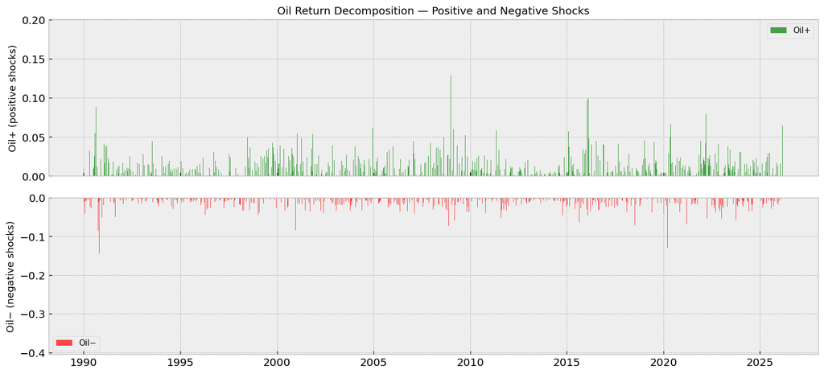

```python
# Plot Oil+ and Oil- over time
fig, axes = plt.subplots(2, 1, figsize=(13, 6), sharex=True)

axes[0].bar(df_daily.index, df_daily['oil_pos'], color='green',  width=1, alpha=0.7, label='Oil+')
axes[0].set_ylabel('Oil+ (positive shocks)')
axes[0].legend(fontsize=9)

axes[1].bar(df_daily.index, df_daily['oil_neg'], color='red',    width=1, alpha=0.7, label='Oil−')
axes[1].set_ylabel('Oil− (negative shocks)')
axes[1].legend(fontsize=9)

axes[0].set_title('Oil Return Decomposition — Positive and Negative Shocks', fontsize=12)
axes[1].xaxis.set_major_locator(mdates.YearLocator(5))
axes[1].xaxis.set_major_formatter(mdates.DateFormatter('%Y'))

plt.tight_layout()
plt.savefig('plots/oil_asymmetric_decomp.png', bbox_inches='tight')
plt.show()
```

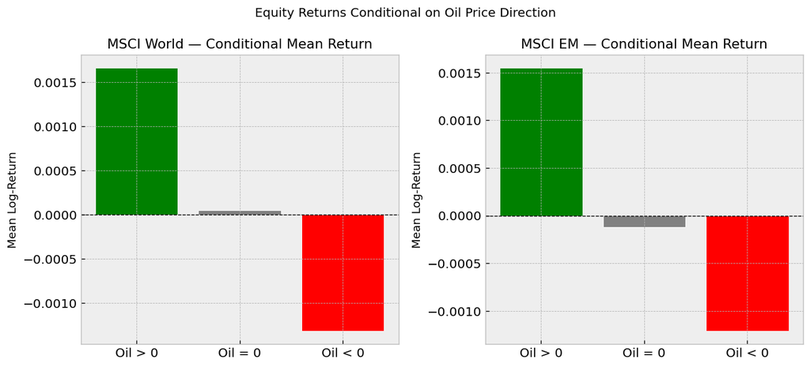

```
            N (Oil>0)  Mean (Oil>0)  N (Oil<0)  Mean (Oil<0)  Difference
Equity
MSCI World       4743      0.001664       4443     -0.001316     0.00298
MSCI EM          4743      0.001550       4443     -0.001210     0.00276
```

```python
# Conditional mean equity return by oil direction
pos_mask = df_daily['roil'] > 0
neg_mask = df_daily['roil'] < 0

fig, axes = plt.subplots(1, 2, figsize=(11, 5))

for ax, col, label in zip(axes,
                          ['rworld', 'rem'],
                          ['MSCI World', 'MSCI EM']):
    means = [
        df_daily.loc[pos_mask, col].mean(),
        df_daily.loc[~pos_mask & ~neg_mask, col].mean(),
        df_daily.loc[neg_mask, col].mean()
    ]
    ax.bar(['Oil > 0', 'Oil = 0', 'Oil < 0'],
           means,
           color=['green', 'gray', 'red'],
           edgecolor='white')
    ax.axhline(0, color='black', linewidth=0.8, linestyle='--')
    ax.set_title(f'{label} — Conditional Mean Return')
    ax.set_ylabel('Mean Log-Return')

plt.suptitle('Equity Returns Conditional on Oil Price Direction', fontsize=12)
plt.tight_layout()
plt.savefig('plots/oil_asymmetric_conditional.png', bbox_inches='tight')
plt.show()

# Summary table
rows = []
for col, label in [('rworld', 'MSCI World'), ('rem', 'MSCI EM')]:
    mean_pos = df_daily.loc[pos_mask, col].mean()
    mean_neg = df_daily.loc[neg_mask, col].mean()
    rows.append({
        'Equity':        label,
        'N (Oil>0)':     int(pos_mask.sum()),
        'Mean (Oil>0)':  mean_pos,
        'N (Oil<0)':     int(neg_mask.sum()),
        'Mean (Oil<0)':  mean_neg,
        'Difference':    mean_pos - mean_neg
    })

df_asymetric = pd.DataFrame(rows).set_index('Equity')
df_asymetric.to_csv('tables/oil_asymmetric.csv', float_format='%.6f')
print(df_asymetric.round(6))
```

# Step 3 — Baseline OLS Models

## 0. Setup

```python
import statsmodels.api as sm

warnings.filterwarnings('ignore')

# Output folders — following step 1 convention
TABLES_DIR = 'tables'
PLOTS_DIR  = 'plots'
os.makedirs(TABLES_DIR, exist_ok=True)
os.makedirs(PLOTS_DIR,  exist_ok=True)

plt.rcParams['figure.dpi'] = 120
plt.rcParams['font.size'] = 11

print('Libraries loaded.')
```

```
Libraries loaded.
```

## 1. Load data

```python
df_daily = pd.read_csv('data/df_daily.csv', index_col=0, parse_dates=True)
df_monthly = pd.read_csv('data/df_monthly.csv', index_col=0, parse_dates=True)

print('Daily  :', df_daily.shape,  '|', df_daily.index[0].date(), 'to', df_daily.index[-1].date())
print('Monthly:', df_monthly.shape, '|', df_monthly.index[0].date(), 'to', df_monthly.index[-1].date())
print()
print('Daily columns :', df_daily.columns.tolist())
print('Monthly columns:', df_monthly.columns.tolist())
```

```
Daily  : (9442, 6) | 1990-01-02 to 2026-03-11
Monthly: (435, 10) | 1990-01-31 to 2026-03-31

Daily columns : ['roil', 'rworld', 'rem', 'rrate', 'oil_pos', 'oil_neg']
Monthly columns: ['roil_monthly', 'rworld_monthly', 'rem_monthly', 'rrate_monthly', 'ip', 'cfnai', 'ism', 'recession', 'oil_pos_m', 'oil_neg_m']
```

## 2. OLS from scratch: core function

This section implements the OLS estimator and extends it to allow Newey–West (HAC) standard errors for robust inference.

The function takes `y` and `X` (without constant), adds the constant internally, and returns:

- `beta` — OLS coefficient estimates
- `se` — standard errors
  - classical OLS if `hac=False`
  - Newey-West HAC if `hac=True`
- `t` — t-statistics computed as $\hat{\beta} / \hat{se}$
- `r2` — coefficient of determination $R^2 = 1 - SSE/SST$
- `resid` — residuals $\hat{u}_t = y_t - \hat{y}_t$

The OLS coefficients are always computed from:

$\hat{\beta} = (X'X)^{-1}X'y$

When `hac=False`, the covariance matrix is:

$\widehat{\mathrm{Var}}(\hat{\beta}) = \hat{\sigma}^2 (X'X)^{-1}$

When `hac=True`, we use a **Newey-West HAC covariance matrix**, which keeps the OLS coefficients unchanged but corrects the inference for heteroskedasticity and weak serial dependence.

We use `np.linalg.pinv` (pseudo-inverse) instead of `np.linalg.inv` to handle near-singular cases more robustly.

```python
def ols_with_const(y, X, x_names=None, hac=False, maxlags=5):
    """
Implements OLS with an intercept from scratch.

Coefficients are estimated using the standard OLS estimator.
Optionally, the covariance matrix can be adjusted using the
Newey–West HAC estimator for robust inference.

    Parameters:

    y       : array-like (T,)
    X       : array-like (T,) or (T, k)   (WITHOUT the constant)
    x_names : list of regressor names (optional)
    hac     : bool, if True compute Newey-West HAC standard errors
    maxlags : int, HAC truncation lag (used only if hac=True)

    Returns:

    dict with keys: beta, se, t, yhat, resid, r2, sigma2, vcov, columns, nobs, dof, cov_type, maxlags
    """
    y = np.asarray(y, dtype=float).reshape(-1, 1)
    X = np.asarray(X, dtype=float)
    if X.ndim == 1:
        X = X.reshape(-1, 1)

    # Drop observations where y or any X is missing / non-finite
    ok = np.isfinite(y).flatten()
    for j in range(X.shape[1]):
        ok = ok & np.isfinite(X[:, j])
    y, X = y[ok], X[ok]

    T = y.shape[0]
    Xc = np.column_stack([np.ones(T), X])   # add constant as first column
    k  = Xc.shape[1]

    # OLS formula
    XtX     = Xc.T @ Xc
    Xty     = Xc.T @ y
    XtX_inv = np.linalg.pinv(XtX)           # pseudo-inverse: handles near-singular X'X
    beta    = (XtX_inv @ Xty).flatten()

    yhat  = Xc @ beta
    resid = y.flatten() - yhat

    # Goodness of fit
    sse = float(np.dot(resid, resid))
    sst = float(np.dot(y.flatten() - y.mean(), y.flatten() - y.mean()))
    r2  = 1.0 - sse / sst if sst > 0 else np.nan

    dof = T - k #degrees of freedom
    sigma2 = sse / dof #classical residual variance


    # Standard errors and covariance matrix
    if not hac:
        vcov = sigma2 * XtX_inv
        cov_type = 'Classical OLS'
    else:
        # Newey-West "meat" matrix
        # S = sum_t e_t^2 x_t x_t' + sum_l w_l sum_t e_t e_{t-l}(x_t x_{t-l}' + x_{t-l} x_t')
        S = np.zeros((k, k))

        # Lag 0 term
        for t in range(T):
            xt = Xc[t:t+1].T   # (k,1)
            S += resid[t]**2 * (xt @ xt.T)

        # Positive lag terms
        L = min(maxlags, T - 1)
        for ell in range(1, L + 1):
            weight = 1.0 - ell / (L + 1.0)   # Bartlett kernel
            Gamma = np.zeros((k, k))

            for t in range(ell, T):
                xt = Xc[t:t+1].T
                xt_lag = Xc[t - ell:t - ell + 1].T
                Gamma += resid[t] * resid[t - ell] * (xt @ xt_lag.T)

            S += weight * (Gamma + Gamma.T)

        vcov = XtX_inv @ S @ XtX_inv
        cov_type = f'Newey-West HAC (maxlags={maxlags})'

    se = np.sqrt(np.maximum(np.diag(vcov), 0))
    tstat = beta / se
#-----------------------------------------------------
    if x_names is None:
        columns = ['const'] + [f'x{j}' for j in range(1, k)]
    else:
        columns = ['const'] + list(x_names)

    return {
        'beta'   : beta.flatten(),
        'se'     : se.flatten(),
        't'      : tstat.flatten(),
        'yhat'   : yhat.flatten(),
        'resid'  : resid.flatten(),
        'r2'     : r2,
        'sigma2' : float(sigma2),
        'vcov'   : vcov,
        'columns': columns,
        'nobs'   : T,
        'dof'    : dof,
        'cov_type': cov_type,
        'maxlags' : maxlags
    }


def summarize_ols(res, title=''):
    """Return a clean DataFrame with beta, se, t-stat, p-value and stars for significance.

    Uses Normal distribution for p-values when HAC covariance is used (asymptotic),
    and Student-t when classical OLS covariance is used.
    """
    from scipy.stats import t as t_dist, norm
    df = pd.DataFrame(
        {'beta': res['beta'], 'se': res['se'], 't-stat': res['t']},
        index=res['columns']
    )
    # Two-sided p-value:
    # HAC (Newey-West) → asymptotic Normal standard
    # Classical OLS    → Student-t with T-k degrees of freedom
    if res['cov_type'].startswith('Newey-West'):
        df['p-value'] = df['t-stat'].apply(lambda t: 2 * (1 - norm.cdf(abs(t))))
    else:
        dof = res['nobs'] - len(res['columns'])
        df['p-value'] = df['t-stat'].apply(lambda t: 2 * (1 - t_dist.cdf(abs(t), df=dof)))
    # Significance stars (|t| > 1.645 → *, > 1.96 → **, > 2.576 → ***)
    def stars(t):
        at = abs(t)
        if at > 2.576: return '***'
        if at > 1.96:  return '**'
        if at > 1.645: return '*'
        return ''
    df['sig'] = df['t-stat'].apply(stars)
    if title:
        print(f'\n--- {title} ---')
        print(f'  N = {res["nobs"]}   R² = {res["r2"]:.4f}')
    return df

def save_table(df_table, filename, title=None):
    """Save a DataFrame as PNG table in tables/."""
    display_df = df_table.copy()
    for col in display_df.columns:
        display_df[col] = display_df[col].apply(
            lambda x: f'{float(x):.4f}' if isinstance(x, (int, float)) and x != '' else x
        )
    fig, ax = plt.subplots(figsize=(max(7, 1.8 * len(df_table.columns)),
                                    max(2, 0.45 * (len(df_table) + 2))))
    ax.axis('off')
    tbl = ax.table(
        cellText=display_df.values,
        rowLabels=display_df.index.tolist(),
        colLabels=display_df.columns.tolist(),
        loc='center', cellLoc='center'
    )
    tbl.auto_set_font_size(False)
    tbl.set_fontsize(9)
    tbl.scale(1, 1.3)
    if title:
        ax.set_title(title, pad=12, fontsize=10)
    plt.tight_layout()
    path = os.path.join(TABLES_DIR, filename)
    fig.savefig(path, dpi=200, bbox_inches='tight')
    plt.close(fig)
    print(f'  → saved: {path}')
```

```python
def ljungbox_resid(res, label='', lags=[5, 10, 20]):
    """
    Applies the Ljung–Box test to OLS residuals.
    Null hypothesis: residuals are not autocorrelated up to lag k.

    Used to verify whether HAC standard errors have adequately addressed
    the autocorrelation present in the residuals.
    """
    from statsmodels.stats.diagnostic import acorr_ljungbox
    lb = acorr_ljungbox(res['resid'], lags=lags, return_df=True)
    lb['Reject H0 (5%)'] = lb['lb_pvalue'].apply(lambda p: 'Yes' if p < 0.05 else 'No')
    if label:
        print(f'Ljung-Box residual test — {label}')
    print(lb[['lb_stat', 'lb_pvalue', 'Reject H0 (5%)']].round(4).to_string())
    print()
```

```python
# --- Quick sanity check ---
np.random.seed(0)
_T = 200
_x = np.random.randn(_T)
_y = 1.0 + 2.0 * _x + np.random.randn(_T)
_res = ols_with_const(_y, _x, ['x'], hac=True)
print('Sanity check — true: const=1.0, beta=2.0')
display(summarize_ols(_res, 'Sanity check'))
```

```
Sanity check — true: const=1.0, beta=2.0

--- Sanity check ---
  N = 200   R² = 0.8348
```

|  | beta | se | t-stat | p-value | sig |
| --- | --- | --- | --- | --- | --- |
| const | 0.867034 | 0.058237 | 14.888082 | 0.0 | *** |
| x | 2.069825 | 0.070945 | 29.175114 | 0.0 | *** |

### Statsmodels verification

We confirm that our from-scratch implementation matches `statsmodels.OLS` on the sanity-check data.

```python
_check = sm.OLS(_y, sm.add_constant(_x)).fit()

print('From scratch  — const: {:.6f}  beta: {:.6f}'.format(_res['beta'][0], _res['beta'][1]))
print('Statsmodels   — const: {:.6f}  beta: {:.6f}'.format(_check.params[0], _check.params[1]))
print('Max difference:', np.max(np.abs(_res['beta'] - _check.params)))
print('✓ Both implementations agree.')
```

```
From scratch  — const: 0.867034  beta: 2.069825
Statsmodels   — const: 0.867034  beta: 2.069825
Max difference: 4.440892098500626e-16
✓ Both implementations agree.
```

## 3. Baseline OLS Models (Daily frequency)

We estimate two baseline regressions on **daily log-returns**:

$$r_{world,t} = \alpha + \beta_1 r_{oil,t} + \beta_2 r_{rate,t} + \varepsilon_t$$

$$r_{em,t} = \alpha + \beta_1 r_{oil,t} + \beta_2 r_{rate,t} + \varepsilon_t$$

where:

- $r_{oil,t}$ = Brent oil log-return
- $r_{rate,t}$ = change in US 10Y yield
- $r_{world,t}$ = MSCI World log-return
- $r_{em,t}$ = MSCI Emerging Markets log-return

**Interpretation of $\beta_1$**: a 1% increase in oil prices is associated with a $\beta_1$% change in equity returns, controlling for the interest rate.

```python
# Regressors: oil return + rate change
X_base = df_daily[['roil', 'rrate']].values

# Model 1: MSCI World
y_world = df_daily['rworld'].values
res_world = ols_with_const(y_world, X_base, ['roil', 'rrate'], hac=True, maxlags=5)

# Model 2: MSCI EM
y_em = df_daily['rem'].values
res_em = ols_with_const(y_em, X_base, ['roil', 'rrate'], hac=True, maxlags=5)

# Display results
tbl_world = summarize_ols(res_world, 'Baseline — MSCI World (daily)')
display(tbl_world.round(4))
print(f'  N = {res_world["nobs"]}   R² = {res_world["r2"]:.4f}')

tbl_em = summarize_ols(res_em, 'Baseline — MSCI EM (daily)')
display(tbl_em.round(4))
print(f'  N = {res_em["nobs"]}   R² = {res_em["r2"]:.4f}')
```

```
--- Baseline — MSCI World (daily) ---
  N = 9442   R² = 0.0666
```

|  | beta | se | t-stat | p-value | sig |
| --- | --- | --- | --- | --- | --- |
| const | 0.0002 | 0.0001 | 2.1509 | 0.0315 | ** |
| roil | 0.0765 | 0.0124 | 6.1755 | 0.0000 | *** |
| rrate | 0.0265 | 0.0032 | 8.1572 | 0.0000 | *** |

```
  N = 9442   R² = 0.0666

--- Baseline — MSCI EM (daily) ---
  N = 9442   R² = 0.0382
```

|  | beta | se | t-stat | p-value | sig |
| --- | --- | --- | --- | --- | --- |
| const | 0.0002 | 0.0001 | 1.5213 | 0.1282 |  |
| roil | 0.0790 | 0.0130 | 6.0849 | 0.0000 | *** |
| rrate | 0.0189 | 0.0028 | 6.7929 | 0.0000 | *** |

```
  N = 9442   R² = 0.0382
```

```python
# Ljung-Box residual tests — Baseline models
ljungbox_resid(res_world, 'Baseline MSCI World (daily)')
ljungbox_resid(res_em,    'Baseline MSCI EM (daily)')
```

```
Ljung-Box residual test — Baseline MSCI World (daily)
     lb_stat  lb_pvalue Reject H0 (5%)
5   141.8445        0.0            Yes
10  184.8965        0.0            Yes
20  212.2939        0.0            Yes

Ljung-Box residual test — Baseline MSCI EM (daily)
     lb_stat  lb_pvalue Reject H0 (5%)
5   412.1324        0.0            Yes
10  449.1370        0.0            Yes
20  494.0388        0.0            Yes
```

```python
# Combined summary table
summary_baseline = pd.DataFrame({
    'World_beta': res_world['beta'],
    'World_tstat': res_world['t'],
    'EM_beta': res_em['beta'],
    'EM_tstat': res_em['t'],
}, index=res_world['columns'])

# Add N and R2 as footer rows
footer = pd.DataFrame({
    'World_beta': [res_world['nobs'], res_world['r2']],
    'World_tstat': ['', ''],
    'EM_beta': [res_em['nobs'], res_em['r2']],
    'EM_tstat': ['', ''],
}, index=['N', 'R²'])

summary_baseline_full = pd.concat([summary_baseline, footer])

summary_baseline.to_csv(os.path.join(TABLES_DIR, 'ols_baseline_daily.csv'))
save_table(summary_baseline.round(4), 'ols_baseline_daily.png',
           'Baseline OLS — Daily (MSCI World vs EM)')
display(summary_baseline.round(4))
```

```
  → saved: tables\ols_baseline_daily.png
```

|  | World_beta | World_tstat | EM_beta | EM_tstat |
| --- | --- | --- | --- | --- |
| const | 0.0002 | 2.1509 | 0.0002 | 1.5213 |
| roil | 0.0765 | 6.1755 | 0.0790 | 6.0849 |
| rrate | 0.0265 | 8.1572 | 0.0189 | 6.7929 |

### Residual plots — baseline models

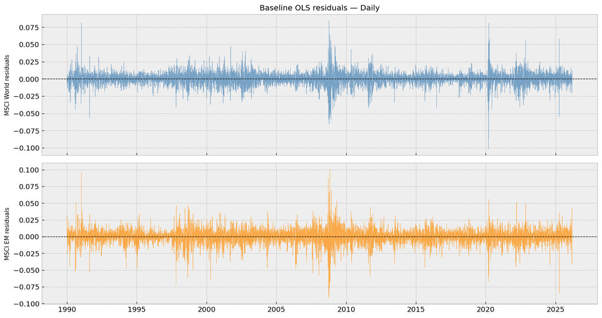

```
  → saved: plots/ols_baseline_residuals.png
```

```python
fig, axes = plt.subplots(2, 1, figsize=(13, 7), sharex=True)

for ax, res, label, color in zip(
    axes,
    [res_world, res_em],
    ['MSCI World', 'MSCI EM'],
    ['steelblue', 'darkorange']
):
    ax.plot(df_daily.index, res['resid'], color=color, linewidth=0.4, alpha=0.7)
    ax.axhline(0, color='black', linewidth=0.8, linestyle='--')
    ax.set_ylabel(f'{label} residuals', fontsize=9)
    ax.xaxis.set_major_locator(mdates.YearLocator(5))
    ax.xaxis.set_major_formatter(mdates.DateFormatter('%Y'))

axes[0].set_title('Baseline OLS residuals — Daily', fontsize=12)
plt.tight_layout()
plt.savefig(os.path.join(PLOTS_DIR, 'ols_baseline_residuals.png'), bbox_inches='tight')
plt.show()
print('  → saved: plots/ols_baseline_residuals.png')
```

## 4. Asymmetric Oil Model

Oil price increases and decreases may have **asymmetric effects** on equity markets — a key hypothesis in the literature (Hamilton, 2003; Kilian & Park, 2009).

We decompose oil returns into:

- $Oil^+_t = \max(r_{oil,t}, 0)$ — positive oil shocks (price increases)
- $Oil^-_t = \min(r_{oil,t}, 0)$ — negative oil shocks (price decreases)

The model becomes:

$$r_{world,t} = \alpha + \beta_1 Oil^+_t + \beta_2 Oil^-_t + \beta_3 r_{rate,t} + \varepsilon_t$$

**Test of asymmetry**: if $\beta_1 \neq \beta_2$, oil shocks are asymmetric.

This decomposition was already computed in Step 1 (`oil_pos`, `oil_neg`).

```python
X_asym = df_daily[['oil_pos', 'oil_neg', 'rrate']].values

# --- Model 3: Asymmetric — MSCI World ---
res_asym_world = ols_with_const(y_world, X_asym, ['oil_pos', 'oil_neg', 'rrate'], hac=True, maxlags=5)

# --- Model 4: Asymmetric — MSCI EM ---
res_asym_em = ols_with_const(y_em, X_asym, ['oil_pos', 'oil_neg', 'rrate'], hac=True, maxlags=5)

tbl_asym_world = summarize_ols(res_asym_world, 'Asymmetric — MSCI World (daily)')
display(tbl_asym_world.round(4))
print(f'  N = {res_asym_world["nobs"]}   R² = {res_asym_world["r2"]:.4f}')

tbl_asym_em = summarize_ols(res_asym_em, 'Asymmetric — MSCI EM (daily)')
display(tbl_asym_em.round(4))
print(f'  N = {res_asym_em["nobs"]}   R² = {res_asym_em["r2"]:.4f}')
```

```
--- Asymmetric — MSCI World (daily) ---
  N = 9442   R² = 0.0677
```

|  | beta | se | t-stat | p-value | sig |
| --- | --- | --- | --- | --- | --- |
| const | 0.0005 | 0.0002 | 2.1313 | 0.0331 | ** |
| oil_pos | 0.0555 | 0.0133 | 4.1727 | 0.0000 | *** |
| oil_neg | 0.0948 | 0.0259 | 3.6659 | 0.0002 | *** |
| rrate | 0.0264 | 0.0032 | 8.1867 | 0.0000 | *** |

```
  N = 9442   R² = 0.0677

--- Asymmetric — MSCI EM (daily) ---
  N = 9442   R² = 0.0389
```

|  | beta | se | t-stat | p-value | sig |
| --- | --- | --- | --- | --- | --- |
| const | 0.0005 | 0.0003 | 1.7616 | 0.0781 | * |
| oil_pos | 0.0589 | 0.0149 | 3.9581 | 0.0001 | *** |
| oil_neg | 0.0965 | 0.0280 | 3.4473 | 0.0006 | *** |
| rrate | 0.0188 | 0.0028 | 6.7852 | 0.0000 | *** |

```
  N = 9442   R² = 0.0389
```

```python
# Ljung-Box residual tests,  Asymmetric models
ljungbox_resid(res_asym_world, 'Asymmetric MSCI World (daily)')
ljungbox_resid(res_asym_em,    'Asymmetric MSCI EM (daily)')
```

```
Ljung-Box residual test — Asymmetric MSCI World (daily)
     lb_stat  lb_pvalue Reject H0 (5%)
5   143.0930        0.0            Yes
10  184.7098        0.0            Yes
20  212.5966        0.0            Yes

Ljung-Box residual test — Asymmetric MSCI EM (daily)
     lb_stat  lb_pvalue Reject H0 (5%)
5   412.5808        0.0            Yes
10  449.0307        0.0            Yes
20  493.6355        0.0            Yes
```

```python
# Test of asymmetry: H0: beta(oil_pos) = beta(oil_neg)
# A simple t-test on the difference: t = (b_pos - b_neg) / se_diff
# se_diff = sqrt(Var(b_pos) + Var(b_neg) - 2*Cov(b_pos, b_neg))

def asymmetry_test(res, idx_pos=1, idx_neg=2):
    """Test H0: beta(oil_pos) = beta(oil_neg)."""
    b_pos = res['beta'][idx_pos]
    b_neg = res['beta'][idx_neg]
    var_pos = res['vcov'][idx_pos, idx_pos]
    var_neg = res['vcov'][idx_neg, idx_neg]
    cov_pn  = res['vcov'][idx_pos, idx_neg]
    diff    = b_pos - b_neg
    se_diff = np.sqrt(var_pos + var_neg - 2 * cov_pn)
    t_diff  = diff / se_diff
    return diff, se_diff, t_diff

for label, res in [('MSCI World', res_asym_world), ('MSCI EM', res_asym_em)]:
    diff, se_d, t_d = asymmetry_test(res)
    print(f'{label}: beta_pos - beta_neg = {diff:.4f}  (t = {t_d:.3f})')
    print(f'  → Asymmetry is', 'significant at 5%' if abs(t_d) > 1.96 else 'NOT significant at 5%')
```

```
MSCI World: beta_pos - beta_neg = -0.0393  (t = -1.169)
  → Asymmetry is NOT significant at 5%
MSCI EM: beta_pos - beta_neg = -0.0376  (t = -1.006)
  → Asymmetry is NOT significant at 5%
```

```python
# Save asymmetric results table
summary_asym = pd.DataFrame({
    'World_beta': res_asym_world['beta'],
    'World_tstat': res_asym_world['t'],
    'EM_beta': res_asym_em['beta'],
    'EM_tstat': res_asym_em['t'],
}, index=res_asym_world['columns'])

summary_asym.to_csv(os.path.join(TABLES_DIR, 'ols_asymmetric_daily.csv'))
save_table(summary_asym.round(4), 'ols_asymmetric_daily.png',
           'Asymmetric OLS — Daily (oil_pos / oil_neg)')
display(summary_asym.round(4))
```

```
  → saved: tables\ols_asymmetric_daily.png
```

|  | World_beta | World_tstat | EM_beta | EM_tstat |
| --- | --- | --- | --- | --- |
| const | 0.0005 | 2.1313 | 0.0005 | 1.7616 |
| oil_pos | 0.0555 | 4.1727 | 0.0589 | 3.9581 |
| oil_neg | 0.0948 | 3.6659 | 0.0965 | 3.4473 |
| rrate | 0.0264 | 8.1867 | 0.0188 | 6.7852 |

## 5. Macro Interaction Models (Monthly frequency)

The central question of the project: **does the oil effect differ during recessions?**

We use the **CFNAI** (Chicago Fed National Activity Index) to identify recession periods: $$Recession_t = \mathbf{1}[CFNAI_t < -0.7]$$

This threshold is standard in the literature — CFNAI below -0.7 is associated with recessionary conditions.

The interaction model is:

$$r_{world,t} = \alpha + \beta_1 r_{oil,t} + \beta_2 Recession_t + \beta_3 (r_{oil,t} \times Recession_t) + \varepsilon_t$$

- $\beta_1$: oil effect in normal times
- $\beta_1 + \beta_3$: oil effect during recessions
- $\beta_3$: **the key coefficient**: does the oil effect change in bad times?

```python
# Drop the 1 missing observation (Jan 1990)
df_m = df_monthly.dropna(subset=['rworld_monthly', 'rem_monthly']).copy()

print(f'Monthly sample: {df_m.index[0].date()} to {df_m.index[-1].date()}')
print(f'N = {len(df_m)}, recession months = {df_m["recession"].sum()}')

# Build interaction term
df_m['oil_x_recession'] = df_m['roil_monthly'] * df_m['recession']

# Regressors for interaction model
X_inter = df_m[['roil_monthly', 'recession', 'oil_x_recession']].values

y_world_m = df_m['rworld_monthly'].values
y_em_m    = df_m['rem_monthly'].values

# Model 5: Macro interaction — MSCI World (monthly)
res_inter_world = ols_with_const(
    y_world_m, X_inter,
    ['roil_monthly', 'recession', 'oil x recession'],
    hac=True, maxlags=3
)

# Model 6: Macro interaction — MSCI EM (monthly)
res_inter_em = ols_with_const(
    y_em_m, X_inter,
    ['roil_monthly', 'recession', 'oil x recession'],
    hac=True, maxlags=3
)

tbl_inter_world = summarize_ols(res_inter_world, 'Macro interaction — MSCI World (monthly)')
display(tbl_inter_world.round(4))
print(f'  N = {res_inter_world["nobs"]}   R² = {res_inter_world["r2"]:.4f}')

tbl_inter_em = summarize_ols(res_inter_em, 'Macro interaction — MSCI EM (monthly)')
display(tbl_inter_em.round(4))
print(f'  N = {res_inter_em["nobs"]}   R² = {res_inter_em["r2"]:.4f}')
```

```
Monthly sample: 1990-02-28 to 2026-03-31
N = 434, recession months = 35

--- Macro interaction — MSCI World (monthly) ---
  N = 434   R² = 0.0649
```

|  | beta | se | t-stat | p-value | sig |
| --- | --- | --- | --- | --- | --- |
| const | 0.0054 | 0.0018 | 2.9023 | 0.0037 | *** |
| roil_monthly | 0.0912 | 0.0312 | 2.9239 | 0.0035 | *** |
| recession | -0.0076 | 0.0123 | -0.6139 | 0.5393 |  |
| oil x recession | 0.0597 | 0.1012 | 0.5902 | 0.5550 |  |

```
  N = 434   R² = 0.0649

--- Macro interaction — MSCI EM (monthly) ---
  N = 434   R² = 0.0622
```

|  | beta | se | t-stat | p-value | sig |
| --- | --- | --- | --- | --- | --- |
| const | 0.0044 | 0.0031 | 1.4075 | 0.1593 |  |
| roil_monthly | 0.1386 | 0.0397 | 3.4935 | 0.0005 | *** |
| recession | -0.0015 | 0.0205 | -0.0749 | 0.9403 |  |
| oil x recession | 0.0841 | 0.1400 | 0.6006 | 0.5481 |  |

```
  N = 434   R² = 0.0622
```

```python
# Ljung-Box residual tests -> Interaction models (monthly)
ljungbox_resid(res_inter_world, 'Interaction MSCI World (monthly)')
ljungbox_resid(res_inter_em,    'Interaction MSCI EM (monthly)')
```

```
Ljung-Box residual test — Interaction MSCI World (monthly)
    lb_stat  lb_pvalue Reject H0 (5%)
5    5.1564     0.3971             No
10   9.7147     0.4659             No
20  17.5254     0.6186             No

Ljung-Box residual test — Interaction MSCI EM (monthly)
    lb_stat  lb_pvalue Reject H0 (5%)
5   13.1338     0.0222            Yes
10  18.6748     0.0446            Yes
20  34.9824     0.0202            Yes
```

```python
# Economic interpretation: total oil effect by regime
print('=== Total oil effect by regime ===')
print()
for label, res in [('MSCI World', res_inter_world), ('MSCI EM', res_inter_em)]:
    b_oil     = res['beta'][1]   # beta on roil_monthly
    b_inter   = res['beta'][3]   # beta on oil x recession
    oil_normal = b_oil
    oil_recession = b_oil + b_inter
    print(f'{label}:')
    print(f'  Normal times  : {oil_normal:.4f}  (beta_oil = {b_oil:.4f})')
    print(f'  Recession     : {oil_recession:.4f}  (beta_oil + beta_interaction = {oil_recession:.4f})')
    print(f'  Difference    : {b_inter:.4f}  (t = {res["t"][3]:.3f})')
    print()
```

```
=== Total oil effect by regime ===

MSCI World:
  Normal times  : 0.0912  (beta_oil = 0.0912)
  Recession     : 0.1509  (beta_oil + beta_interaction = 0.1509)
  Difference    : 0.0597  (t = 0.590)

MSCI EM:
  Normal times  : 0.1386  (beta_oil = 0.1386)
  Recession     : 0.2227  (beta_oil + beta_interaction = 0.2227)
  Difference    : 0.0841  (t = 0.601)
```

```python
# Save interaction results
summary_inter = pd.DataFrame({
    'World_beta': res_inter_world['beta'],
    'World_tstat': res_inter_world['t'],
    'EM_beta': res_inter_em['beta'],
    'EM_tstat': res_inter_em['t'],
}, index=res_inter_world['columns'])

# Add N and R2
extra = pd.DataFrame({
    'World_beta': [res_inter_world['nobs'], round(res_inter_world['r2'], 4)],
    'World_tstat': ['', ''],
    'EM_beta': [res_inter_em['nobs'], round(res_inter_em['r2'], 4)],
    'EM_tstat': ['', ''],
}, index=['N', 'R²'])

summary_inter_full = pd.concat([summary_inter, extra])
summary_inter_full.to_csv(os.path.join(TABLES_DIR, 'ols_interaction_monthly.csv'))
save_table(summary_inter_full, 'ols_interaction_monthly.png',
           'Macro Interaction OLS — Monthly (CFNAI recession dummy)')
display(summary_inter_full)
```

```
  → saved: tables\ols_interaction_monthly.png
```

|  | World_beta | World_tstat | EM_beta | EM_tstat |
| --- | --- | --- | --- | --- |
| const | 0.005363 | 2.90231 | 0.004363 | 1.407482 |
| roil_monthly | 0.091164 | 2.923927 | 0.138553 | 3.493466 |
| recession | -0.007557 | -0.613884 | -0.001537 | -0.074874 |
| oil x recession | 0.059738 | 0.590222 | 0.084103 | 0.600556 |
| N | 434.000000 |  | 434.000000 |  |
| R² | 0.064900 |  | 0.062200 |  |

### Visualisation: oil effect in recession vs normal times

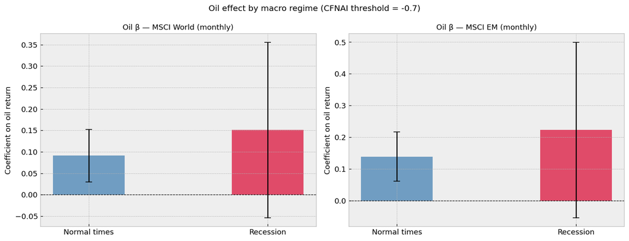

```
  → saved: plots/ols_oil_effect_by_regime.png
```

```python
fig, axes = plt.subplots(1, 2, figsize=(13, 5))

for ax, res, label in zip(axes,
                           [res_inter_world, res_inter_em],
                           ['MSCI World', 'MSCI EM']):
    b_oil   = res['beta'][1]
    b_inter = res['beta'][3]
    se_oil  = res['se'][1]
    se_int  = res['se'][3]

    regimes = ['Normal times', 'Recession']
    betas   = [b_oil, b_oil + b_inter]
    errors  = [se_oil, np.sqrt(se_oil**2 + se_int**2 +
                                2 * res['vcov'][1, 3])]

    colors = ['steelblue', 'crimson']
    bars = ax.bar(regimes, betas, color=colors, alpha=0.75, width=0.4)
    ax.errorbar(regimes, betas, yerr=[1.96 * e for e in errors],
                fmt='none', color='black', capsize=5, linewidth=1.5)
    ax.axhline(0, color='black', linewidth=0.8, linestyle='--')
    ax.set_title(f'Oil β — {label} (monthly)', fontsize=11)
    ax.set_ylabel('Coefficient on oil return')

plt.suptitle('Oil effect by macro regime (CFNAI threshold = -0.7)', fontsize=12)
plt.tight_layout()
plt.savefig(os.path.join(PLOTS_DIR, 'ols_oil_effect_by_regime.png'), bbox_inches='tight')
plt.show()
print('  → saved: plots/ols_oil_effect_by_regime.png')
```

### Recession periods on the sample

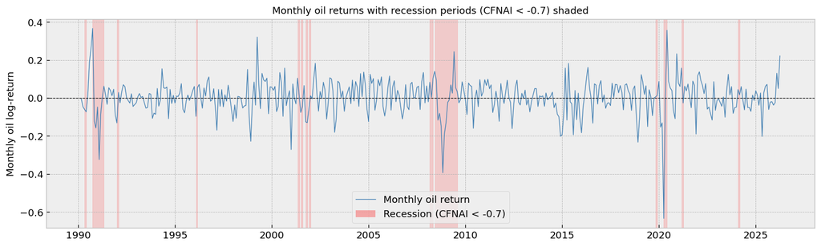

```
  → saved: plots/recession_periods.png
```

```python
fig, ax = plt.subplots(figsize=(13, 4))

ax.plot(df_m.index, df_m['roil_monthly'], color='steelblue', linewidth=0.8,
        label='Monthly oil return')

# Shade recession periods
in_rec = False
rec_start = None
for date, row in df_m.iterrows():
    if row['recession'] == 1 and not in_rec:
        rec_start = date
        in_rec = True
    elif row['recession'] == 0 and in_rec:
        ax.axvspan(rec_start, date, color='red', alpha=0.15)
        in_rec = False
if in_rec:
    ax.axvspan(rec_start, df_m.index[-1], color='red', alpha=0.15)

ax.axhline(0, color='black', linewidth=0.7, linestyle='--')
ax.set_ylabel('Monthly oil log-return')
ax.set_title('Monthly oil returns with recession periods (CFNAI < -0.7) shaded', fontsize=11)
ax.xaxis.set_major_locator(mdates.YearLocator(5))
ax.xaxis.set_major_formatter(mdates.DateFormatter('%Y'))

from matplotlib.patches import Patch
ax.legend(handles=[
    ax.lines[0],
    Patch(facecolor='red', alpha=0.3, label='Recession (CFNAI < -0.7)')
])

plt.tight_layout()
plt.savefig(os.path.join(PLOTS_DIR, 'recession_periods.png'), bbox_inches='tight')
plt.show()
print('  → saved: plots/recession_periods.png')
```

## 6. Summary of all baseline models

We consolidate all results in a single comparison table.

```python
def make_row(label, res, coef_name):
    """Extract a specific coefficient row for the summary table."""
    cols = res['columns']
    if coef_name not in cols:
        return None
    idx = cols.index(coef_name)
    b = res['beta'][idx]
    t = res['t'][idx]
    stars = '***' if abs(t) > 2.576 else ('**' if abs(t) > 1.96 else ('*' if abs(t) > 1.645 else ''))
    return {'Model': label, 'Coef': coef_name,
            'beta': round(b, 4), 't-stat': round(t, 3), 'sig': stars,
            'N': res['nobs'], 'R2': round(res['r2'], 4)}

rows = [
    make_row('Baseline World (daily)',    res_world,       'roil'),
    make_row('Baseline EM (daily)',       res_em,          'roil'),
    make_row('Asymmetric World (daily)',  res_asym_world,  'oil_pos'),
    make_row('Asymmetric World (daily)',  res_asym_world,  'oil_neg'),
    make_row('Asymmetric EM (daily)',     res_asym_em,     'oil_pos'),
    make_row('Asymmetric EM (daily)',     res_asym_em,     'oil_neg'),
    make_row('Interaction World (monthly)', res_inter_world, 'roil_monthly'),
    make_row('Interaction World (monthly)', res_inter_world, 'oil x recession'),
    make_row('Interaction EM (monthly)',    res_inter_em,    'roil_monthly'),
    make_row('Interaction EM (monthly)',    res_inter_em,    'oil x recession'),
]

summary_all = pd.DataFrame([r for r in rows if r is not None])
summary_all.to_csv(os.path.join(TABLES_DIR, 'ols_all_models_summary.csv'), index=False)
save_table(summary_all, 'ols_all_models_summary.png', 'All baseline OLS models — key coefficients')
display(summary_all)
```

```
  → saved: tables\ols_all_models_summary.png
```

|  | Model | Coef | beta | t-stat | sig | N | R2 |
| --- | --- | --- | --- | --- | --- | --- | --- |
| 0 | Baseline World (daily) | roil | 0.0765 | 6.176 | *** | 9442 | 0.0666 |
| 1 | Baseline EM (daily) | roil | 0.0790 | 6.085 | *** | 9442 | 0.0382 |
| 2 | Asymmetric World (daily) | oil_pos | 0.0555 | 4.173 | *** | 9442 | 0.0677 |
| 3 | Asymmetric World (daily) | oil_neg | 0.0948 | 3.666 | *** | 9442 | 0.0677 |
| 4 | Asymmetric EM (daily) | oil_pos | 0.0589 | 3.958 | *** | 9442 | 0.0389 |
| 5 | Asymmetric EM (daily) | oil_neg | 0.0965 | 3.447 | *** | 9442 | 0.0389 |
| 6 | Interaction World (monthly) | roil_monthly | 0.0912 | 2.924 | *** | 434 | 0.0649 |
| 7 | Interaction World (monthly) | oil x recession | 0.0597 | 0.590 |  | 434 | 0.0649 |
| 8 | Interaction EM (monthly) | roil_monthly | 0.1386 | 3.493 | *** | 434 | 0.0622 |
| 9 | Interaction EM (monthly) | oil x recession | 0.0841 | 0.601 |  | 434 | 0.0622 |

## 7. Files saved

**tables/** — CSV + PNG tables

| File | Content |
| --- | --- |
| `ols_baseline_daily.csv/png` | Baseline World & EM (daily) |
| `ols_asymmetric_daily.csv/png` | Asymmetric oil model (daily) |
| `ols_interaction_monthly.csv/png` | Macro interaction with recession dummy (monthly) |
| `ols_all_models_summary.csv/png` | All key coefficients |

**plots/** — Figures

[output not shown]

# Step 4 — OLS Robustness Checks

## 0. Setup

## 1. Load data

```python
# df_monthly is already loaded above (Step 1)
# Drop the single missing observation (Jan 1990 — no Dec 1989 price for EOM returns)
df_m = df_monthly.dropna(subset=['rworld_monthly', 'rem_monthly']).copy()

print(f'Monthly sample: {df_m.index[0].date()} to {df_m.index[-1].date()}')
print(f'N = {len(df_m)}')
print()
print(df_m[['roil_monthly', 'ip', 'cfnai', 'ism', 'recession']].describe().round(3))
```

```
Monthly sample: 1990-02-28 to 2026-03-31
N = 434

       roil_monthly       ip    cfnai      ism  recession
count       434.000  433.000  433.000  433.000    434.000
mean          0.004   90.449   -0.073   52.216      0.081
std           0.093   12.821    1.115    4.884      0.273
min          -0.634   60.335  -18.260   34.500      0.000
25%          -0.046   86.202   -0.290   49.000      0.000
50%           0.008   95.026    0.010   52.600      0.000
75%           0.061  100.285    0.240   55.700      0.000
max           0.366  104.100    6.300   63.800      1.000
```

## 3. Robustness Check 1 — Industrial Production (IP)

We replace the CFNAI dummy with an **IP dummy**: $$IP\_low_t = \mathbf{1}[IP_t < \text{median}(IP)]$$

The model: $$r_{world,t} = \alpha + \beta_1 r_{oil,t} + \beta_2 IP\_low_t + \beta_3 (r_{oil,t} \times IP\_low_t) + \varepsilon_t$$

**Why IP?** Industrial production is a direct measure of real economic activity. Periods below the median historically coincide with economic slowdowns and may amplify the impact of oil price changes on equity markets.

**Why median?** Unlike CFNAI, IP has a trend (grows over time), so using a fixed threshold would be misleading. The median splits the sample into roughly equal halves.

```python
# Build IP dummy: 1 when IP is below its sample median (weak activity)
ip_median = df_m['ip'].median()
df_m['ip_low'] = (df_m['ip'] < ip_median).astype(int)

print(f'IP median: {ip_median:.2f}')
print(f'IP_low months: {df_m["ip_low"].sum()} / {len(df_m)} ({df_m["ip_low"].mean()*100:.1f}%)')

# Build interaction term
df_m['oil_x_ip_low'] = df_m['roil_monthly'] * df_m['ip_low']

X_ip = df_m[['roil_monthly', 'ip_low', 'oil_x_ip_low']].values.astype(float)

# Estimate for World and EM
res_ip_world = ols_with_const(
    df_m['rworld_monthly'].values, X_ip,
    ['roil_monthly', 'ip_low', 'oil x ip_low'],
    hac=True, maxlags=3
)
res_ip_em = ols_with_const(
    df_m['rem_monthly'].values, X_ip,
    ['roil_monthly', 'ip_low', 'oil x ip_low'],
    hac=True, maxlags=3
)

display(summarize_ols(res_ip_world, 'Robustness 1 (IP) — MSCI World').round(4))
print(f'  N = {res_ip_world["nobs"]}   R² = {res_ip_world["r2"]:.4f}')

display(summarize_ols(res_ip_em, 'Robustness 1 (IP) — MSCI EM').round(4))
print(f'  N = {res_ip_em["nobs"]}   R² = {res_ip_em["r2"]:.4f}')
```

```
IP median: 95.03
IP_low months: 216 / 434 (49.8%)

--- Robustness 1 (IP) — MSCI World ---
  N = 434   R² = 0.0718
```

|  | beta | se | t-stat | p-value | sig |
| --- | --- | --- | --- | --- | --- |
| const | 0.0055 | 0.0022 | 2.4704 | 0.0135 | ** |
| roil_monthly | 0.1678 | 0.0335 | 5.0141 | 0.0000 | *** |
| ip_low | -0.0018 | 0.0041 | -0.4264 | 0.6698 |  |
| oil x ip_low | -0.1061 | 0.0808 | -1.3129 | 0.1892 |  |

```
  N = 434   R² = 0.0718

--- Robustness 1 (IP) — MSCI EM ---
  N = 434   R² = 0.0669
```

|  | beta | se | t-stat | p-value | sig |
| --- | --- | --- | --- | --- | --- |
| const | 0.0031 | 0.0033 | 0.9631 | 0.3355 |  |
| roil_monthly | 0.2271 | 0.0362 | 6.2672 | 0.0000 | *** |
| ip_low | 0.0017 | 0.0066 | 0.2595 | 0.7953 |  |
| oil x ip_low | -0.1213 | 0.1050 | -1.1556 | 0.2478 |  |

```
  N = 434   R² = 0.0669
```

```python
# Ljung-Box residual tests — Robustness Check 1 (IP)
ljungbox_resid(res_ip_world, 'Robustness IP — MSCI World')
ljungbox_resid(res_ip_em,    'Robustness IP — MSCI EM')
```

```
Ljung-Box residual test — Robustness IP — MSCI World
    lb_stat  lb_pvalue Reject H0 (5%)
5    6.4337     0.2663             No
10  11.5950     0.3131             No
20  22.2321     0.3280             No

Ljung-Box residual test — Robustness IP — MSCI EM
    lb_stat  lb_pvalue Reject H0 (5%)
5   13.5925     0.0184            Yes
10  19.7306     0.0319            Yes
20  37.0185     0.0116            Yes
```

```python
# Economic interpretation: total oil effect by IP regime
print('=== Oil effect by IP regime ===')
for label, res in [('MSCI World', res_ip_world), ('MSCI EM', res_ip_em)]:
    b_oil  = res['beta'][1]
    b_int  = res['beta'][3]
    print(f'{label}:')
    print(f'  Normal IP (above median) : {b_oil:.4f}  (t = {res["t"][1]:.3f})')
    print(f'  Low IP (below median)    : {b_oil + b_int:.4f}  (t_interaction = {res["t"][3]:.3f})')
    print()
```

```
=== Oil effect by IP regime ===
MSCI World:
  Normal IP (above median) : 0.1678  (t = 5.014)
  Low IP (below median)    : 0.0616  (t_interaction = -1.313)

MSCI EM:
  Normal IP (above median) : 0.2271  (t = 6.267)
  Low IP (below median)    : 0.1058  (t_interaction = -1.156)
```

## 4. Robustness Check 2 — Manufacturing ISM

We replace the CFNAI dummy with an **ISM dummy**: $$ISM\_contr_t = \mathbf{1}[ISM_t < 50]$$

The model: $$r_{world,t} = \alpha + \beta_1 r_{oil,t} + \beta_2 ISM\_contr_t + \beta_3 (r_{oil,t} \times ISM\_contr_t) + \varepsilon_t$$

**Why ISM < 50?** The ISM Manufacturing Index measures business conditions in the US manufacturing sector. A reading below 50 indicates **contraction** — this is the standard threshold used by practitioners and the financial press. It is a forward-looking indicator, making it particularly relevant for asset pricing.

```python
# Build ISM contraction dummy: 1 when ISM < 50 (manufacturing contraction)
df_m['ism_contr'] = (df_m['ism'] < 50).astype(int)

print(f'ISM contraction months: {df_m["ism_contr"].sum()} / {len(df_m)} ({df_m["ism_contr"].mean()*100:.1f}%)')
print(f'ISM mean: {df_m["ism"].mean():.2f},  ISM min: {df_m["ism"].min():.2f}')

df_m['oil_x_ism'] = df_m['roil_monthly'] * df_m['ism_contr']
X_ism = df_m[['roil_monthly', 'ism_contr', 'oil_x_ism']].values.astype(float)

res_ism_world = ols_with_const(
    df_m['rworld_monthly'].values, X_ism,
    ['roil_monthly', 'ism_contr', 'oil x ism_contr'],
    hac=True, maxlags=3
)
res_ism_em = ols_with_const(
    df_m['rem_monthly'].values, X_ism,
    ['roil_monthly', 'ism_contr', 'oil x ism_contr'],
    hac=True, maxlags=3
)

display(summarize_ols(res_ism_world, 'Robustness 2 (ISM) — MSCI World').round(4))
print(f'  N = {res_ism_world["nobs"]}   R² = {res_ism_world["r2"]:.4f}')

display(summarize_ols(res_ism_em, 'Robustness 2 (ISM) — MSCI EM').round(4))
print(f'  N = {res_ism_em["nobs"]}   R² = {res_ism_em["r2"]:.4f}')
```

```
ISM contraction months: 135 / 434 (31.1%)
ISM mean: 52.22,  ISM min: 34.50

--- Robustness 2 (ISM) — MSCI World ---
  N = 434   R² = 0.0630
```

|  | beta | se | t-stat | p-value | sig |
| --- | --- | --- | --- | --- | --- |
| const | 0.0040 | 0.0022 | 1.8687 | 0.0617 | * |
| roil_monthly | 0.1454 | 0.0330 | 4.4110 | 0.0000 | *** |
| ism_contr | 0.0001 | 0.0053 | 0.0268 | 0.9786 |  |
| oil x ism_contr | -0.0644 | 0.0858 | -0.7514 | 0.4524 |  |

```
  N = 434   R² = 0.0630

--- Robustness 2 (ISM) — MSCI EM ---
  N = 434   R² = 0.0608
```

|  | beta | se | t-stat | p-value | sig |
| --- | --- | --- | --- | --- | --- |
| const | 0.0026 | 0.0036 | 0.7156 | 0.4742 |  |
| roil_monthly | 0.1934 | 0.0440 | 4.3919 | 0.0000 | *** |
| ism_contr | 0.0030 | 0.0079 | 0.3793 | 0.7044 |  |
| oil x ism_contr | -0.0528 | 0.1072 | -0.4929 | 0.6221 |  |

```
  N = 434   R² = 0.0608
```

```python
# Ljung-Box residual tests — Robustness Check 2 (ISM)
ljungbox_resid(res_ism_world, 'Robustness ISM — MSCI World')
ljungbox_resid(res_ism_em,    'Robustness ISM — MSCI EM')
```

```
Ljung-Box residual test — Robustness ISM — MSCI World
    lb_stat  lb_pvalue Reject H0 (5%)
5    5.5659     0.3508             No
10   9.9475     0.4451             No
20  19.2820     0.5036             No

Ljung-Box residual test — Robustness ISM — MSCI EM
    lb_stat  lb_pvalue Reject H0 (5%)
5   13.8535     0.0166            Yes
10  20.5472     0.0245            Yes
20  37.3356     0.0107            Yes
```

```python
print('=== Oil effect by ISM regime ===')
for label, res in [('MSCI World', res_ism_world), ('MSCI EM', res_ism_em)]:
    b_oil  = res['beta'][1]
    b_int  = res['beta'][3]
    print(f'{label}:')
    print(f'  ISM >= 50 (expansion)    : {b_oil:.4f}  (t = {res["t"][1]:.3f})')
    print(f'  ISM < 50  (contraction)  : {b_oil + b_int:.4f}  (t_interaction = {res["t"][3]:.3f})')
    print()
```

```
=== Oil effect by ISM regime ===
MSCI World:
  ISM >= 50 (expansion)    : 0.1454  (t = 4.411)
  ISM < 50  (contraction)  : 0.0810  (t_interaction = -0.751)

MSCI EM:
  ISM >= 50 (expansion)    : 0.1934  (t = 4.392)
  ISM < 50  (contraction)  : 0.1405  (t_interaction = -0.493)
```

## 5. Robustness Check 3 — CFNAI continuous (no dummy)

Instead of binarising the CFNAI into a recession dummy, we use the **raw continuous CFNAI value** as both a level control and in the interaction:

$$r_{world,t} = \alpha + \beta_1 r_{oil,t} + \beta_2 CFNAI_t + \beta_3 (r_{oil,t} \times CFNAI_t) + \varepsilon_t$$

This specification avoids the arbitrary threshold of -0.7, using the **full variation** of the CFNAI.

```python
# CFNAI continuous interaction
df_m['oil_x_cfnai'] = df_m['roil_monthly'] * df_m['cfnai']

X_cfnai = df_m[['roil_monthly', 'cfnai', 'oil_x_cfnai']].values.astype(float)

res_cfnai_world = ols_with_const(
    df_m['rworld_monthly'].values, X_cfnai,
    ['roil_monthly', 'cfnai', 'oil x cfnai'],
    hac=True, maxlags=3
)
res_cfnai_em = ols_with_const(
    df_m['rem_monthly'].values, X_cfnai,
    ['roil_monthly', 'cfnai', 'oil x cfnai'],
    hac=True, maxlags=3
)

display(summarize_ols(res_cfnai_world, 'Robustness 3 (CFNAI continuous) — MSCI World').round(4))
print(f'  N = {res_cfnai_world["nobs"]}   R² = {res_cfnai_world["r2"]:.4f}')

display(summarize_ols(res_cfnai_em, 'Robustness 3 (CFNAI continuous) — MSCI EM').round(4))
print(f'  N = {res_cfnai_em["nobs"]}   R² = {res_cfnai_em["r2"]:.4f}')
```

```
--- Robustness 3 (CFNAI continuous) — MSCI World ---
  N = 433   R² = 0.0693
```

|  | beta | se | t-stat | p-value | sig |
| --- | --- | --- | --- | --- | --- |
| const | 0.0049 | 0.0020 | 2.4989 | 0.0125 | ** |
| roil_monthly | 0.1047 | 0.0430 | 2.4345 | 0.0149 | ** |
| cfnai | -0.0007 | 0.0027 | -0.2642 | 0.7916 |  |
| oil x cfnai | -0.0239 | 0.0113 | -2.1165 | 0.0343 | ** |

```
  N = 433   R² = 0.0693

--- Robustness 3 (CFNAI continuous) — MSCI EM ---
  N = 433   R² = 0.0702
```

|  | beta | se | t-stat | p-value | sig |
| --- | --- | --- | --- | --- | --- |
| const | 0.0045 | 0.0033 | 1.3527 | 0.1762 |  |
| roil_monthly | 0.1558 | 0.0529 | 2.9477 | 0.0032 | *** |
| cfnai | -0.0010 | 0.0028 | -0.3781 | 0.7054 |  |
| oil x cfnai | -0.0326 | 0.0130 | -2.5075 | 0.0122 | ** |

```
  N = 433   R² = 0.0702
```

```python
# --- Ljung-Box residual tests — Robustness Check 3 (CFNAI continu) ---
ljungbox_resid(res_cfnai_world, 'Robustness CFNAI continu — MSCI World')
ljungbox_resid(res_cfnai_em,    'Robustness CFNAI continu — MSCI EM')
```

```
Ljung-Box residual test — Robustness CFNAI continu — MSCI World
    lb_stat  lb_pvalue Reject H0 (5%)
5    6.0013     0.3061             No
10  10.7133     0.3803             No
20  19.1715     0.5107             No

Ljung-Box residual test — Robustness CFNAI continu — MSCI EM
    lb_stat  lb_pvalue Reject H0 (5%)
5   14.6514     0.0120            Yes
10  20.2322     0.0271            Yes
20  37.1978     0.0111            Yes
```

```python
print('=== Oil effect at selected CFNAI levels ===')
print('(Total oil effect = beta_oil + beta_interaction * CFNAI)')
print()
cfnai_scenarios = {'Severe recession (CFNAI=-2)': -2.0,
                   'Mild recession (CFNAI=-0.7)': -0.7,
                   'Normal (CFNAI=0)': 0.0,
                   'Expansion (CFNAI=+1)': 1.0}

for label, res in [('MSCI World', res_cfnai_world), ('MSCI EM', res_cfnai_em)]:
    b_oil  = res['beta'][1]
    b_int  = res['beta'][3]
    print(f'{label}  (beta_oil={b_oil:.4f}, beta_interaction={b_int:.4f}):')
    for scenario, cfnai_val in cfnai_scenarios.items():
        total_effect = b_oil + b_int * cfnai_val
        print(f'  {scenario}: {total_effect:.4f}')
    print()
```

```
=== Oil effect at selected CFNAI levels ===
(Total oil effect = beta_oil + beta_interaction * CFNAI)

MSCI World  (beta_oil=0.1047, beta_interaction=-0.0239):
  Severe recession (CFNAI=-2): 0.1525
  Mild recession (CFNAI=-0.7): 0.1214
  Normal (CFNAI=0): 0.1047
  Expansion (CFNAI=+1): 0.0808

MSCI EM  (beta_oil=0.1558, beta_interaction=-0.0326):
  Severe recession (CFNAI=-2): 0.2211
  Mild recession (CFNAI=-0.7): 0.1786
  Normal (CFNAI=0): 0.1558
  Expansion (CFNAI=+1): 0.1232
```